# ALY6015 Module 2: Chi-Square Testing and ANOVA

Kevin Ogudugu

07/20/24

This paper is a presentation of various solutions to a variety of problems incorporating methods such as Chi-Square Test, ANOVA, and two-way ANOVA Testing in Module 2 for ALY6015. Each question follows the conventional steps in testing hypotheses which include stating hypotheses, finding critical values, computing test values, making decisions and summarizing results.

# Task 1 (Section 11-1 6. Blood Types)

**Part A - State the Hypothesis and identify the claim**

- H0: The hospital patients in a large hospital have the same blood type distribution as those in the general population.
- H1: The hospital patients in a large hospital do not have the same blood type distribution as those in the general population.

**Part B - Find the critical value**

```r
alpha <- 0.10
```

**Part C - Compute the test values**

**Vector for the observed values**

```r
observed <- c(12, 8, 24, 6)
```

**Vector for the probabilities**

```r
p <- c(0.20, 0.28, 0.36, 0.16)
```

**Running Chi-squared test and record the result**

```r
result <- chisq.test(x = observed, p = p)
```

**P-value and test statistic**

```r
result$p.value # Chi-square p-value
```

```
## [1] 0.1403575
```

```r
result$statistic # Chi-square test value
```

```
## X-squared
##  5.471429
```

```r
result$parameter # Df
```

```
## df
##  3
```

**Part D - Make the decision**

```r
ifelse(result$p.value > alpha, "Fail to reject the null hypothesis", "Reject the null hypothesis")
```

```
## [1] "Fail to reject the null hypothesis"
```

**Part E - Summarize the results** We fail to reject the null hypothesis at the 0.10 significance level. Hence, there is not enough evidence to claim that the distribution of blood types among the general population is different from the hospital group.

# Task 2 (Section 11-1. 8. On-Time Performance by Airlines)

**Part A - State the hypotheses and identify the claim** - H0: The on-time performance distribution by the airlines is the same as the government´s statistics - H1: The on-time performance distribution differ from the government’s statistics.

**Part B - Find the critical value**

```r
alpha <- 0.05
```

**Part C - Compute the test values**

**Vector for the observed values**

```r
observed <- c(125, 40, 10, 25)
```

**Vector for the probabilities**

```r
p <- c(0.708, 0.082, 0.09, 0.12)
```

**Running Chi-squared test and record the result**

```r
result <- chisq.test(x = observed, p = p)
```

**P-value and test statistic**

```r
result$p.value # Chi-square p-value
```

```
## [1] 1.357151e-08
```

```r
result$statistic # Chi-square test value
```

```
## X-squared
##  39.50424
```

```r
result$parameter # Df
```

```
## df
##  3
```

**Part D - Make the decision**

```r
ifelse(result$p.value > alpha, "Fail to reject the null hypothesis", "Reject the null hypothesis")
```

```
## [1] "Reject the null hypothesis"
```

**Part E - Summarize the results** We reject the null hypothesis at the 0.05 significance level. Hence, there is enough evidence to claim that the distribution of on-time performance differs from the government’s statistics.

**Datasource:**www.transtats.bts.gov

# Task 3 (Section 11-2.8. Ethnicity and Movie Admissions)

**Part A - State the hypotheses and identify the claim**

- H0: Movie attendance by year is independent on ethnicity
- H1: Movie attendance by year is dependent on ethnicity

**Part B - Find the critical value**

```r
alpha <- 0.05
```

**Part C - Compute the test values**

**Row values**

```r
r1 <- c(724, 335, 174, 107)
r2 <- c(370, 292, 152, 140)
```

**Number of rows**

```r
rows = 2
```

**Matrix for the rows**

```r
mtrx = matrix(c(r1, r2), nrow = rows, byrow = TRUE)
```

**Naming rows**

```r
rownames(mtrx) = c("2013", "2014")
colnames(mtrx) = c("Caucasian", "Hispanic", "African American", "Other")
```

**Run the test and record results**

```r
result <- chisq.test(mtrx)
result
```

```
##
##  Pearson's Chi-squared test
##
## data:  mtrx
## X-squared = 60.144, df = 3, p-value = 5.478e-13
```

**View the p-value and test statistic**

```r
result$p.value # Chi-square p-value
```

```
## [1] 5.477507e-13
```

```r
result$statistic # Chi-square test value
```

```
## X-squared
##  60.14352
```

```r
result$parameter # Df
```

```
## df
##  3
```

**Part D - Make the decision**

```r
ifelse(result$p.value > alpha, "Fail to reject the null hypothesis", "Reject the null hypothesis")
```

```
## [1] "Reject the null hypothesis"
```

**Part E - Summarize the results** We reject the null hypothesis at the 0.05 significance level. Hence, there is enough evidence to claim that movie attendance by year depends on ethnicity.

**Datasource:**MPAA Study

# Task 4 (Section 11-2.10 Women in the Military)

**Part A - State the hypotheses and identify the claim** - H0: No relationship exists between rank and branch of the Armed Forces. - H1: There is a relationship between rank and branch of the Armed Forces.

**Part B - Find the critical value**

```r
alpha <- 0.05
```

**Part C - Compute the test values**

**Rows values**

```r
r1 <- c(10791, 62491)
r2 <- c(7816, 42750)
r3 <- c(932, 9525)
r4 <- c(11819, 54344)
```

**number of rows**

```r
rows = 4
```

**Matrix for the rows**

```r
mtrx = matrix(c(r1, r2, r3, r4), nrow = rows, byrow = TRUE)
```

**Naming rows**

```r
rownames(mtrx) = c("Army", "Navy", "Marine Corps", "Air Force")
colnames(mtrx) = c("Officers", "Enlisted")
```

**Run the test and record results**

```r
result <- chisq.test(mtrx)
result
```

```
##
##  Pearson's Chi-squared test
##
## data:  mtrx
## X-squared = 654.27, df = 3, p-value < 2.2e-16
```

**View the p-value and test statistic**

```r
result$p.value # Chi-square p-value
```

```
## [1] 1.726418e-141
```

```r
result$statistic # Chi-square test value
```

```
## X-squared
##  654.2719
```

```r
result$parameter # Df
```

```
## df
##  3
```

**Part D - Make the decision**

```r
ifelse(result$p.value > alpha, "Fail to reject the null hypothesis", "Reject the null hypothesis")
```

```
## [1] "Reject the null hypothesis"
```

**Part E - Summarize the results** We reject the null hypothesis at the 0.05 significance level. Hence, there is enough evidence to claim that a relationship exists between rank and branch of the Armed Forces.

**Datasource:**New York Times Almanac.

# Task 5 (Section 12-1.8 Sodium Contents of Foods)

**Part A - State the hypotheses and identify the claim** - H0: μ1 = μ2 = μ3 - H1: At least one mean is different from the others

**Part B - Find the critical value**

```r
alpha <- 0.05
```

**Part C - Compute the test values**

**Create data frames for condiments, cereals, and desserts**

```r
condiments <- data.frame('sodium' = c(270, 130, 230, 180, 80, 70, 200), 'food' = rep('condiments', 7), stringsAsFactors = FALSE)
cereals <- data.frame('sodium' = c(260, 220, 290, 290, 200, 320, 140), 'food' = rep('cereals', 7), stringsAsFactors = FALSE)
desserts <- data.frame('sodium' = c(100, 180, 250, 250, 300, 360, 300, 160), 'food' = rep('desserts', 8), stringsAsFactors = FALSE)
```

**Combine the data frames into one**

```r
sodium <- rbind(condiments, cereals, desserts)
sodium$food <- as.factor(sodium$food)
```

**Run the ANOVA test**

```r
anova <- aov(sodium ~ food, data = sodium)
```

**View the model summary**

```r
summary(anova)
```

```
##             Df Sum Sq Mean Sq F value Pr(>F)
## food         2  27544   13772   2.399  0.118
## Residuals   19 109093    5742
```

**Save summary to an object**

```r
a_summary <- summary(anova)
```

**Degrees of freedom** **k - 1: between group variance - numerator**

```r
df.numerator <- a_summary[[1]][1, "Df"]
df.numerator
```

```
## [1] 2
```

**N - k: within group variance - denominator**

```r
df.denominator <- a_summary[[1]][2, "Df"]
df.denominator
```

```
## [1] 19
```

**Extract the F test value from the summary**

```r
F.value <- a_summary[[1]][1, "F value"]
F.value
```

```
## [1] 2.398538
```

**Extract the p-value from the summary**

```r
p.value <- a_summary[[1]][1, "Pr(>F)"]
p.value
```

```
## [1] 0.1178108
```

**Part D - Make the decision**

```r
decision <- ifelse(p.value > alpha, "Fail to reject the null hypothesis", "Reject the null hypothesis")
decision
```

```
## [1] "Fail to reject the null hypothesis"
```

**Part E - Summarize the results** We fail to reject the null hypothesis at the 0.05 significance level. Hence, there is not sufficient evidence to claim that a difference in mean sodium amounts exists among condiments, cereals, and desserts.

**Datasource:**The Doctor’s Pocket Calorie, Fat, and Carbohydrate Counter.

# Task 6 (Section 12-2.10 Sales for Leading Companies)

**Part A - State the hypotheses and identify the claim** - H0: μ1 = μ2 = μ3 - H1: At least one mean is different from the others

**Part B - Find the critical value**

```r
alpha <- 0.01
```

**Part C - Compute the test values**

```r
cereal <- data.frame('sales' = c(578, 320, 264, 249, 237), 'category' = rep('cereal', 5), stringsAsFactors = FALSE)
chocolate_candy <- data.frame('sales' = c(311, 106, 109, 125, 173), 'category' = rep('chocolate_candy', 5), stringsAsFactors = FALSE)
coffee <- data.frame('sales' = c(261, 185, 302, 689), 'category' = rep('coffee', 4), stringsAsFactors = FALSE)
```

**Combine the data frames into one**

```r
sales <- rbind(cereal, chocolate_candy, coffee)
sales$category <- as.factor(sales$category)
```

**Run the ANOVA test**

```r
anova <- aov(sales ~ category, data = sales)
```

**View the model summary**

```r
summary(anova)
```

```
##             Df Sum Sq Mean Sq F value Pr(>F)
## category     2 103770   51885   2.172   0.16
## Residuals   11 262795   23890
```

**Save summary to an object**

```r
a_summary <- summary(anova)
```

**Degrees of freedom** **k - 1: between group variance - numerator**

```r
df.numerator <- a_summary[[1]][1, "Df"]
df.numerator
```

```
## [1] 2
```

**N - k: within group variance - denominator**

```r
df.denominator <- a_summary[[1]][2, "Df"]
df.denominator
```

```
## [1] 11
```

**Extract the F test value from the summary**

```r
F.value <- a_summary[[1]][1, "F value"]
F.value
```

```
## [1] 2.171782
```

**Extract the p-value from the summary**

```r
p.value <- a_summary[[1]][1, "Pr(>F)"]
p.value
```

```
## [1] 0.1603487
```

**Part D - Make the decision**

```r
decision <- ifelse(p.value > alpha, "Fail to reject the null hypothesis", "Reject the null hypothesis")
decision
```

```
## [1] "Fail to reject the null hypothesis"
```

**Part E - Summarize the results** We fail to reject the null hypothesis at the 0.01 significance level. Hence, there is not sufficient evidence to claim that a significant difference in mean of sales for leading companies.

**Datasource:**Information Resources, Inc.

# Task 7 (Section 12-2.12 Per-Pupil Expenditures)

**Part A - State the hypotheses and identify the claim** - H0: μ1 = μ2 = μ3 - H1: At least one mean is different from the others

**Part B - Find the critical value**

```r
alpha <- 0.05
```

**Part C - Compute the test values**

```r
eastern <- data.frame('expenditure' = c(4946, 5953, 6202, 7243, 6113), 'region' = rep('eastern', 5), stringsAsFactors = FALSE)
middle <- data.frame('expenditure' = c(6149, 7451, 6000, 6479), 'region' = rep('middle', 4), stringsAsFactors = FALSE)
western <- data.frame('expenditure' = c(5282, 8605, 6528, 6911), 'region' = rep('western', 4), stringsAsFactors = FALSE)
```

**Combine the data frames into one**

```r
expenditures <- rbind(eastern, middle, western)
expenditures$region <- as.factor(expenditures$region)
```

**Run the ANOVA test**

```r
anova <- aov(expenditure ~ region, data = expenditures)
```

**View the model summary**

```r
summary(anova)
```

```
##             Df  Sum Sq Mean Sq F value Pr(>F)
## region       2 1244588  622294   0.649  0.543
## Residuals   10 9591145  959114
```

**Save summary to an object**

```r
a_summary <- summary(anova)
```

**Degrees of freedom** **k - 1: between group variance - numerator**

```r
df.numerator <- a_summary[[1]][1, "Df"]
df.numerator
```

```
## [1] 2
```

**N - k: within group variance - denominator**

```r
df.denominator <- a_summary[[1]][2, "Df"]
df.denominator
```

```
## [1] 10
```

**Extract the F test value from the summary**

```r
F.value <- a_summary[[1]][1, "F value"]
F.value
```

```
## [1] 0.6488214
```

**Extract the p-value from the summary**

```r
p.value <- a_summary[[1]][1, "Pr(>F)"]
p.value
```

```
## [1] 0.5433264
```

**Part D - Make the decision**

```r
decision <- ifelse(p.value > alpha, "Fail to reject the null hypothesis", "Reject the null hypothesis")
decision
```

```
## [1] "Fail to reject the null hypothesis"
```

**Datasource:**New York Times Almanac.

# Task 8 (Section 12- 3. 10. Increasing Plant Growth)

**Part A - State the hypothesis and find the claim** - H0_0: The means of the different light groups are equal - H0_1: The means of the different light groups are different.

- H0_0: The means of the different plant food groups are equal.
- H0_1: The means of the different plant food groups are different.
- H0_0: There is no interaction between light and plant food.
- H0_1: There is interaction between light and plant food.

**Part B - Find the critical value**

```r
alpha <- 0.05
```

**Part C - Compute the test values**

**Create data frames for growth, light, and food**

```r
data <- data.frame(
  growth = c(9.2, 9.4, 8.9, 8.5, 9.2, 8.9, 7.1, 7.2, 8.5, 5.5, 5.8, 7.6),
  light = rep(c("Grow-light 1", "Grow-light 2"), each = 6),
  food = rep(c("Plant food A", "Plant food B"), each = 3, times = 2)
)
```

**Run the two-way ANOVA test**

```r
anova <- aov(growth ~ light * food, data = data)
```

**View the model summary**

```r
summary(anova)
```

```
##             Df Sum Sq Mean Sq F value  Pr(>F)
## light        1 12.813  12.813  24.562 0.00111 **
## food         1  1.920   1.920   3.681 0.09133 .
## light:food   1  0.750   0.750   1.438 0.26482
## Residuals    8  4.173   0.522
## ---
## Signif. codes:  0 '***' 0.001 '**' 0.01 '*' 0.05 '.' 0.1 ' ' 1
```

**Save summary to an object**

```r
a_summary <- summary(anova)
```

**Extract the F test values from the summary**

```r
F.value_light <- a_summary[[1]]["light", "F value"]
F.value_food <- a_summary[[1]]["food", "F value"]
F.value_interaction <- a_summary[[1]]["light:food", "F value"]
```

**Extract the p-values from the summary**

```r
p.value_light <- a_summary[[1]]["light", "Pr(>F)"]
p.value_food <- a_summary[[1]]["food", "Pr(>F)"]
p.value_interaction <- a_summary[[1]]["light:food", "Pr(>F)"]
```

**Determine the degrees of freedom**

```r
dfn_light <- a_summary[[1]]["light", "Df"]
dfn_food <- a_summary[[1]]["food", "Df"]
dfn_interaction <- a_summary[[1]]["light:food", "Df"]
dfd <- a_summary[[1]]["Residuals", "Df"]
```

**Find the critical F-values**

```r
critical_value_light <- qf(1 - alpha, dfn_light, dfd)
critical_value_food <- qf(1 - alpha, dfn_food, dfd)
critical_value_interaction <- qf(1 - alpha, dfn_interaction, dfd)
```

**Part D - Make the decision**

```r
dec_light <- ifelse(!is.na(p.value_light) && p.value_light < alpha, "Reject the null hypothesis", "Fail to reject the null hypothesis")
dec_food <- ifelse(!is.na(p.value_food) && p.value_food < alpha, "Reject the null hypothesis", "Fail to reject the null hypothesis")
dec_interaction <- ifelse(!is.na(p.value_interaction) && p.value_interaction < alpha, "Reject the null hypothesis", "Fail to reject the null hypothesis")
```

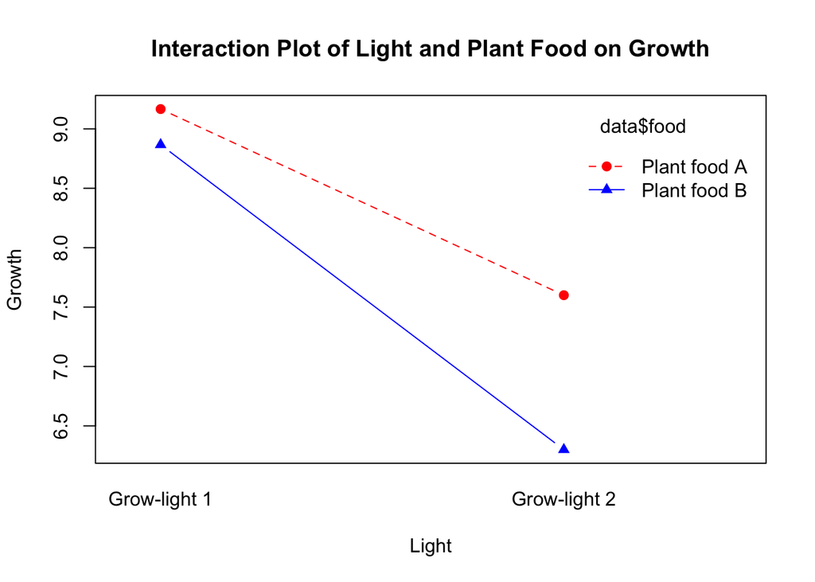

Figure 1: Interaction Plot of Light and Plant Food on Growth

```r
interaction.plot(data$light, data$food, data$growth, col = c("red", "blue"), pch = c(19, 17), type = "b", xlab = "Light", ylab = "Growth", main = "Interaction Plot of Light and Plant Food on Growth")
```

# Task 9

**Libraries**

```r
library(dplyr)
library(tidyverse)
```

**9.1 - Loading the baseball dataset**

```r
baseball <- read.csv("baseball-3.csv")
```

**9.2 - EDA on the baseball dataset**

```r
summary(baseball)
```

```
##      Team              League               Year            RS
##  Length:1232        Length:1232        Min.   :1962   Min.   : 463.0
##  Class :character   Class :character   1st Qu.:1977   1st Qu.: 652.0
##  Mode  :character   Mode  :character   Median :1989   Median : 711.0
##                                        Mean   :1989   Mean   : 715.1
##                                        3rd Qu.:2002   3rd Qu.: 775.0
##                                        Max.   :2012   Max.   :1009.0
##
##        RA               W              OBP              SLG
##  Min.   : 472.0   Min.   : 40.0   Min.   :0.2770   Min.   :0.3010
##  1st Qu.: 649.8   1st Qu.: 73.0   1st Qu.:0.3170   1st Qu.:0.3750
##  Median : 709.0   Median : 81.0   Median :0.3260   Median :0.3960
##  Mean   : 715.1   Mean   : 80.9   Mean   :0.3263   Mean   :0.3973
##  3rd Qu.: 774.2   3rd Qu.: 89.0   3rd Qu.:0.3370   3rd Qu.:0.4210
##  Max.   :1103.0   Max.   :116.0   Max.   :0.3730   Max.   :0.4910
##
##        BA            Playoffs        RankSeason     RankPlayoffs
##  Min.   :0.2140   Min.   :0.0000   Min.   :1.000   Min.   :1.000
##  1st Qu.:0.2510   1st Qu.:0.0000   1st Qu.:2.000   1st Qu.:2.000
##  Median :0.2600   Median :0.0000   Median :3.000   Median :3.000
##  Mean   :0.2593   Mean   :0.1981   Mean   :3.123   Mean   :2.717
##  3rd Qu.:0.2680   3rd Qu.:0.0000   3rd Qu.:4.000   3rd Qu.:4.000
##  Max.   :0.2940   Max.   :1.0000   Max.   :8.000   Max.   :5.000
##                                    NA's   :988     NA's   :988
##        G              OOBP             OSLG
##  Min.   :158.0   Min.   :0.2940   Min.   :0.3460
##  1st Qu.:162.0   1st Qu.:0.3210   1st Qu.:0.4010
##  Median :162.0   Median :0.3310   Median :0.4190
##  Mean   :161.9   Mean   :0.3323   Mean   :0.4197
##  3rd Qu.:162.0   3rd Qu.:0.3430   3rd Qu.:0.4380
##  Max.   :165.0   Max.   :0.3840   Max.   :0.4990
##                  NA's   :812      NA's   :812
```

```r
sum(is.na(baseball))
```

```
## [1] 3600
```

```r
baseball$Year <- as.factor(baseball$Year)
```

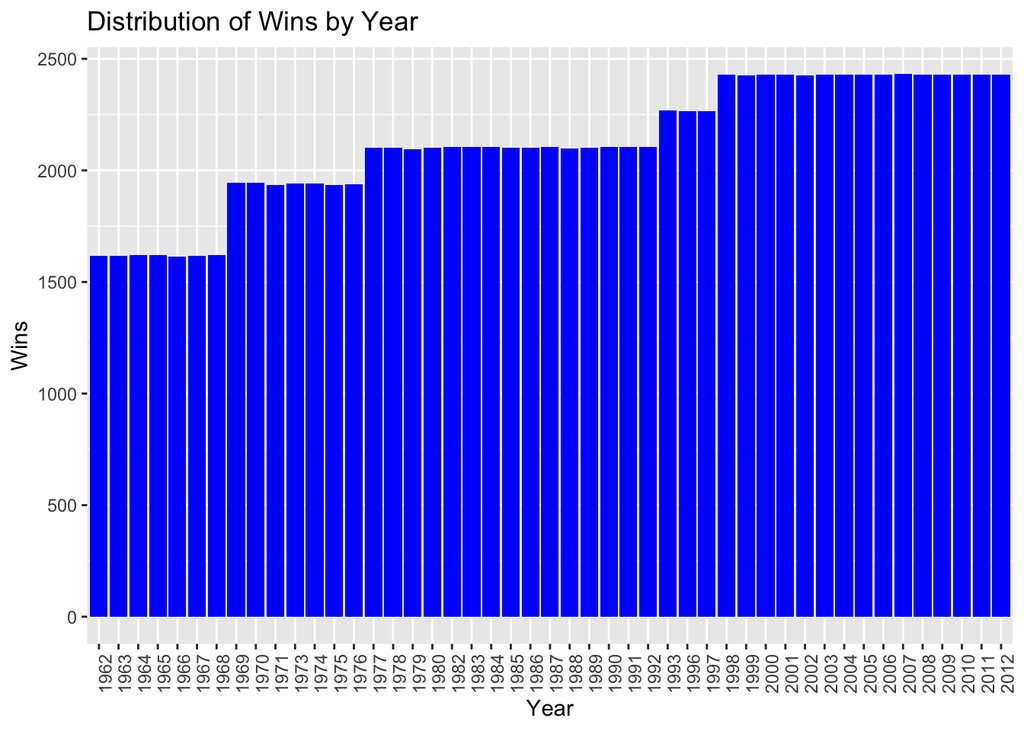

Figure 2: Distribution of Wins by Year

```r
ggplot(baseball, aes(x = Year, y = W)) +
  geom_bar(stat = "identity", fill = "blue") +
  theme(axis.text.x = element_text(angle = 90, hjust = 1)) +
  labs(title = "Distribution of Wins by Year", x = "Year", y = "Wins")
```

**9.3 - Chi-Square Goodness-of-Fit test**

**State the hypothesis and find the claim**

- H0: Number of wins is equally distributed across decades
- H1: Number of wins is not equally distributed across decades

```r
baseball$Decade <- as.factor(as.numeric(as.character(baseball$Year)) - (as.numeric(as.character(baseball$Year)) %% 10))
```

**Create a wins table by summing the wins by decade**

```r
wins <- baseball %>%
  group_by(Decade) %>%
  summarize(wins = sum(W)) %>%
  as_tibble()
```

**Perform Chi-Square Goodness-of-Fit Test**

```r
expected_wins <- sum(wins$wins) / nrow(wins)
chisq_test <- chisq.test(wins$wins, p = rep(1/nrow(wins), nrow(wins)))
```

**Extract test statistic and p-value**

```r
test_statistic <- chisq_test$statistic
p_value <- chisq_test$p.value
```

**Find the critical value**

```r
critical_value <- qchisq(1 - 0.05, df = nrow(wins) - 1)
```

**Make the Decision**

```r
decision <- ifelse(test_statistic > critical_value, "Reject the null hypothesis", "Fail to reject the null hypothesis")
```

**9.4 - Import crop dataset**

```r
cropdata <- read.csv("crop_data-3.csv")
```

**9.5**

**Null and alternate hypothesis**

Fertilizer - H0: The means of the different fertilizer groups are equal. w- H1: The means of the different fertilizer groups are different.

Density - H0: The means of the different density groups are equal. - H1: The means of the different density groups are different.

Interaction - H0: There is no interaction between fertilizer and density. - H1: There is interaction between fertilizer and density.

**Converting the variables density and fertilizer to R factors**

```r
cropdata$density <- as.factor(cropdata$density)
cropdata$fertilizer <- as.factor(cropdata$fertilizer)
```

**Running two-way anova**

```r
anova_result <- aov(yield ~ fertilizer * density, data = cropdata)

summary(anova_result)
```

```
##                    Df Sum Sq Mean Sq F value   Pr(>F)
## fertilizer          2  6.068   3.034   9.001 0.000273 ***
## density             1  5.122   5.122  15.195 0.000186 ***
## fertilizer:density  2  0.428   0.214   0.635 0.532500
## Residuals          90 30.337   0.337
## ---
## Signif. codes:  0 '***' 0.001 '**' 0.01 '*' 0.05 '.' 0.1 ' ' 1
```

```r
a_summary <- summary(anova_result)
```

**Extract the F test values from the summary**

```r
F.value_fertilizer <- a_summary[[1]]["fertilizer", "F value"]
F.value_density <- a_summary[[1]]["density", "F value"]
F.value_interaction <- a_summary[[1]]["fertilizer:density", "F value"]
```

**Extract the p-values from the summary**

```r
p.value_fertilizer <- a_summary[[1]]["fertilizer", "Pr(>F)"]
p.value_density <- a_summary[[1]]["density", "Pr(>F)"]
p.value_interaction <- a_summary[[1]]["fertilizer:density", "Pr(>F)"]
```

**Print extracted values to verify**

```r
p.value_fertilizer
```

[output not shown]

```r
p.value_density
```

```
## [1] 0.0001864075
```

```r
p.value_interaction
```

```
## [1] 0.5325001
```

**Make the decision**

```r
alpha <- 0.05
dec_fertilizer <- ifelse(!is.na(p.value_fertilizer) && p.value_fertilizer < alpha, "Reject the null hypothesis", "Fail to reject the null hypothesis")
dec_density <- ifelse(!is.na(p.value_density) && p.value_density < alpha, "Reject the null hypothesis", "Fail to reject the null hypothesis")
dec_interaction <- ifelse(!is.na(p.value_interaction) && p.value_interaction < alpha, "Reject the null hypothesis", "Fail to reject the null hypothesis")
```

**References:** Bureau of Transportation Statistics. (n.d.). Retrieved from http://www.transtats.bts.gov

New York Times Almanac. (n.d.).

The Doctor’s Pocket Calorie, Fat, and Carbohydrate Counter. (n.d.).

Information Resources, Inc. (n.d.).